# Внешний курс

Безопасность в сети

Солдатов А. Е

Российский университет дружбы народов, Москва, Россия

НКАбд-04-23

9 мая 2025

## Докладчик

- Солдатов Алексей Евгеньевич
- Студент
- НКАбд-04-23
- Российский университет дружбы народов
- 1132236009@pfur.ru

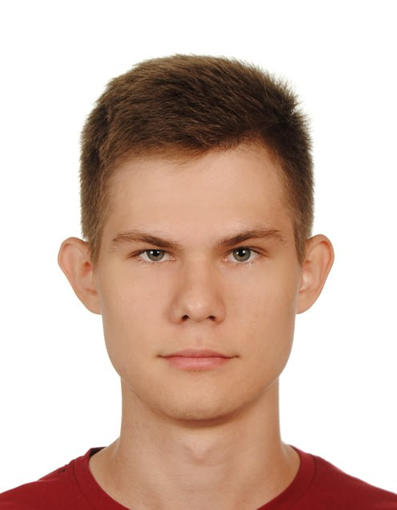

## Выполнение блока 1

После просмотра видеоматериала приступил к выполнению заданий

В видеолекции было сказано, что к протоколам прикладного уровня относится HTTPS (рис. 1 [-@fig:001]).

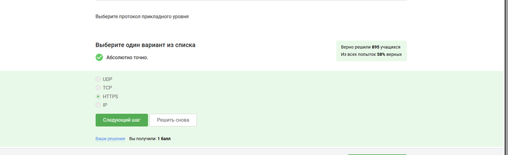

Протокол прикладного уровня

В видеолекции было сказано, что протокол TCP работает на транспортном уровне (рис. 2 [-@fig:002]).

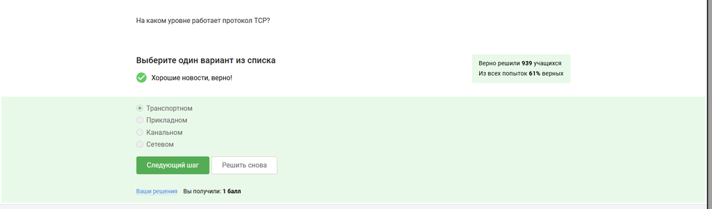

Уровень протокола TCP

В видеолекции было сказано, что числа в адресе формата IPv4 не одлжны быть больше 255 (рис. 3 [-@fig:003]).

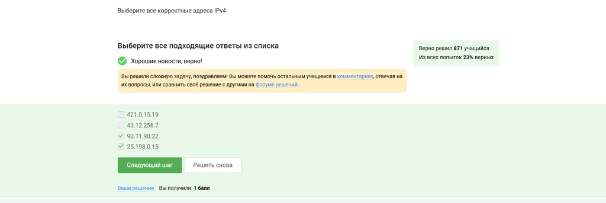

Корректные адреса

В видеолекции было сказано, что DNS сервер сопоставляет IP адреса доменным именам (рис. 4 [-@fig:004]).

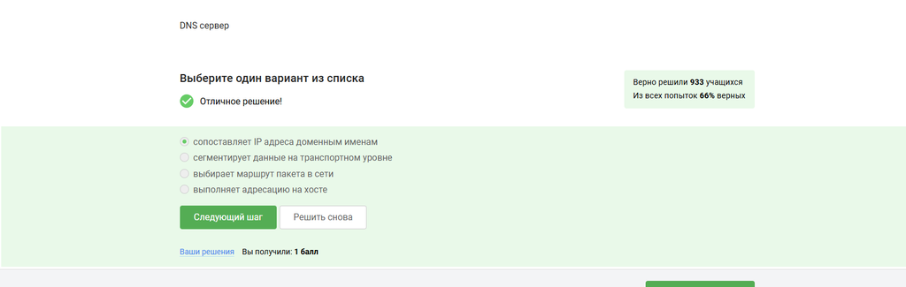

Что делает DNS

В видеолекции было сказано, какой должна быть последовательность у протокола TCP/IP (рис. 5 [-@fig:005]).

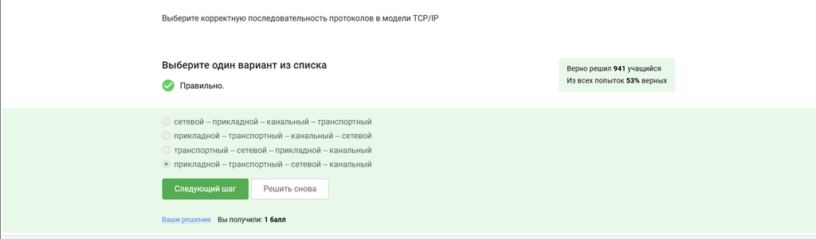

Последовательность у протокола TCP/IP

В видеолекции было сказано, что передача зашифрованных данных осуществляется по протоколу https, а http предполагает передачу данных в открытом виде (рис. 6 [-@fig:006]).

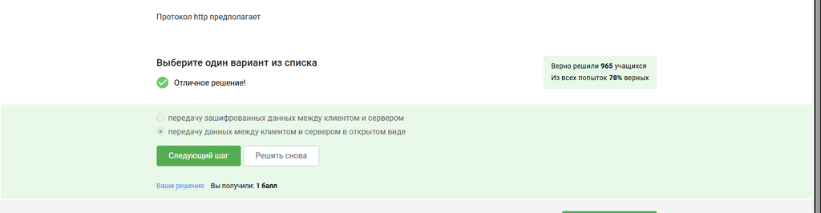

http

В видеолекции было сказано, что протокол https состоит из двух фаз: рукопожатия и передачи данных (рис. 7 [-@fig:007]).

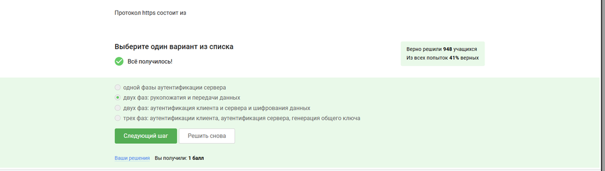

https

В видеолекции было сказано, что версия протокола TLS определяется и клиентом, и сервером (рис. 8 [-@fig:008]).

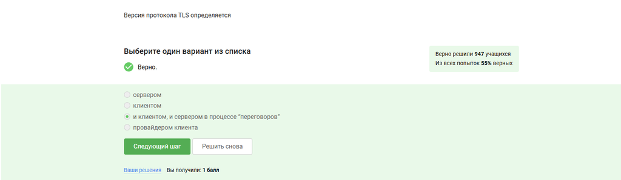

TLS

В видеолекции было сказано, что в фазе “рукопожатия” протокола TLS не предусмотрено шифрование данных (рис. 9 [-@fig:009]).

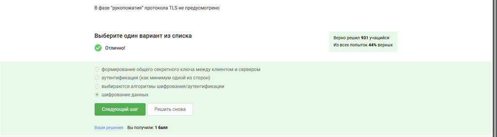

TLS

# Выполнение блока 2

В видеолекции было сказано, что куки хранят id сессии, идентификатор пользователя и не только (рис. 10 [-@fig:010]).

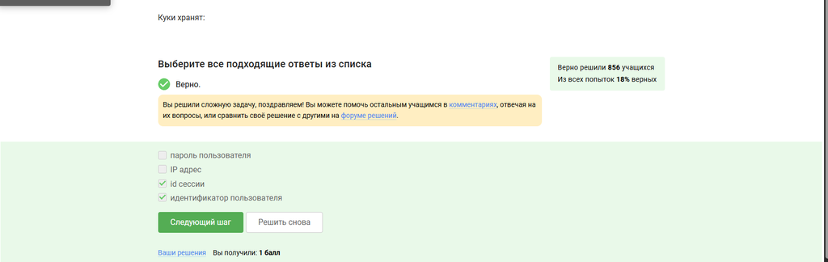

Что хранят куки

В видеолекции было сказано, для чего используются куки, следовательно они не используются для (рис. 11 [-@fig:011]).

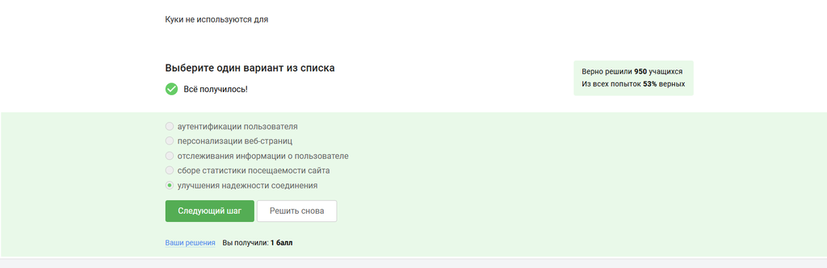

Для чего не используют куки

В видеолекции было сказано, что куки генерируются сервером (рис. 12 [-@fig:012]).

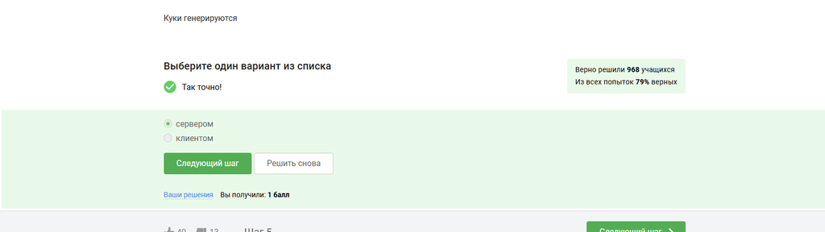

Чем генерируются куки

В видеолекции было сказано, что сессионные куки хранятся в браузере, пока пользуются веб-сайтом (рис. 13 [-@fig:013]).

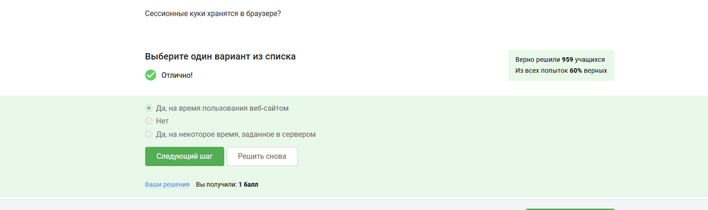

Сессионные куки

# Выполнение блока 3

В видеолекции было сказано, что в луковой сети 3 промежуточных узла (рис. 14 [-@fig:014]).

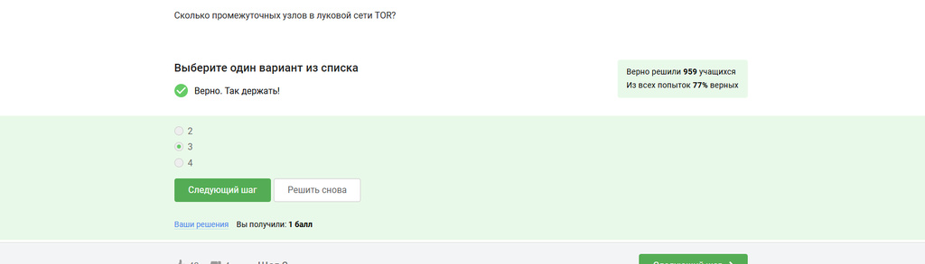

Сколько промежуточных узлов в луковой сети

В видеолекции было сказано, кому известен ip-aдрес получателя (рис. 15 [-@fig:015]).

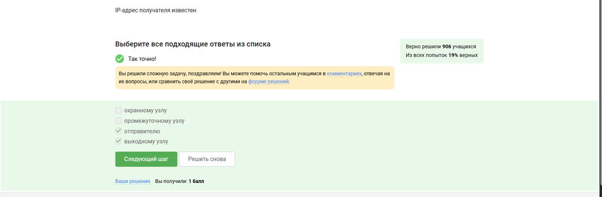

Кому известен IP адрес получателя

В видеолекции было сказано, в каком виде отправитель генерирует общий секретный ключ (рис. 16 [-@fig:016]).

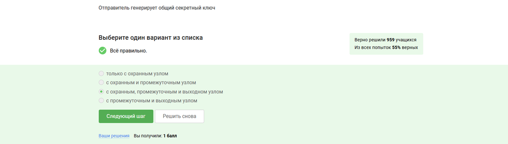

В каком виде отправитель генерирует общий секретный ключ

В видеолекции было сказано, что для успешного получения пакетов не обязательно пользовать Tor (рис. 17 [-@fig:017]).

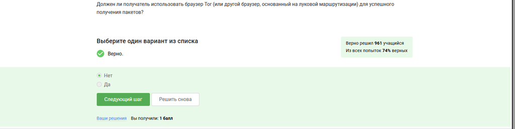

# Выполнение блока 4

В видеолекции было сказано, что такое wi-fi (рис. 18 [-@fig:018]).

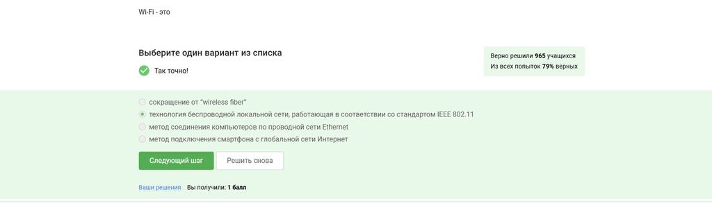

wi-fi

В видеолекции было сказано, на каком уровне работает wi-fi (рис. 19 [-@fig:019]).

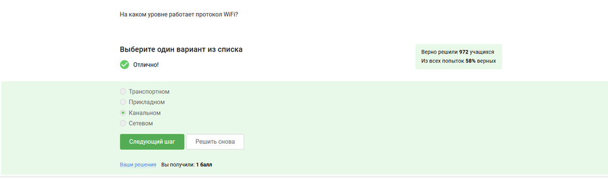

На каком уровне работает wi-fi

В видеолекции было сказано, какой метод является устаревшим и небезопасным в сети wifi (рис. 20 [-@fig:020]).

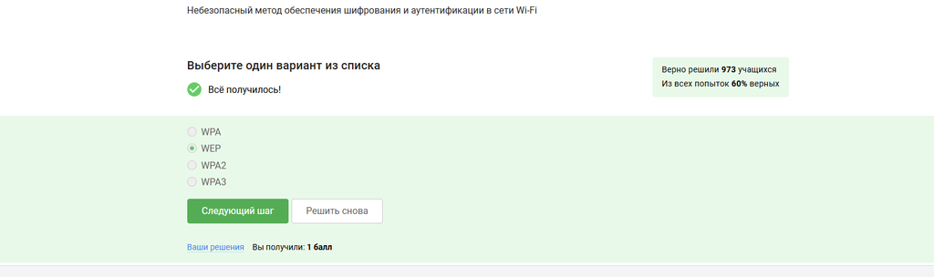

Небезопасный метод в сети wi-fi

В видеолекции было сказано, как должны передаваться данные (рис. 21 [-@fig:021]).

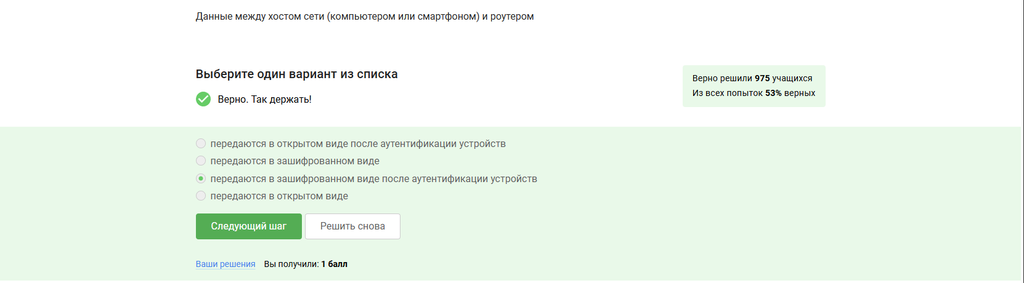

Передача данных

В видеолекции было сказано, какой метод обычно используют в домашних сетях (рис. 22 [-@fig:022]).

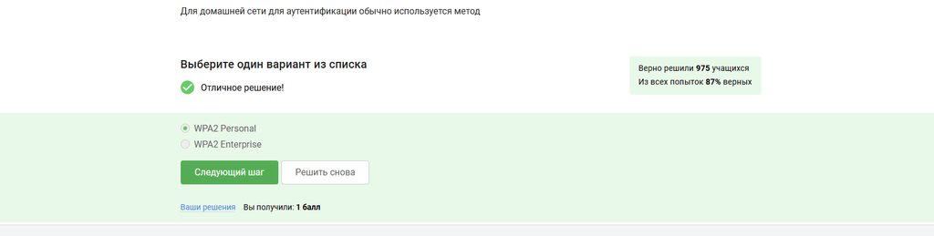

Мето для домашних сетей

# Выводы

Получил полезные знания и прошел тесты по теме безопасность сети